# Análisis de datos del sedentarismo y la activdad física

Carlos de Oro Aguado

2024-11-27

## Análisis exploratorio de las variables sociodemográficas

Realizaremos un análisis de nuestra variables sociodemográficas

|  | SEXO | Frecuencia | Porcentaje |
| --- | --- | --- | --- |
| 1 | Femenino | 80 | 64 |
| 2 | Masculino | 45 | 36 |

La muestra tiene un total de 125 estudiantes donde el 64% son del sexo femenino y el resto del sexo masculino.

|  | PROGRAMA DE FISIOTERAPIA | Frecuencia | Porcentaje |
| --- | --- | --- | --- |
| 1 | 1er semestre | 14 | 11.2 |
| 2 | 2do semestre | 12 | 9.6 |
| 3 | 3er semestre | 29 | 23.2 |
| 4 | 4to semestre | 18 | 14.4 |
| 5 | 5to semestre | 31 | 24.8 |
| 6 | 6to semestre | 5 | 4 |
| 7 | 7mo semestre | 16 | 12.8 |

En la tabla anterior podemos ver que el 24.8% de los estudiantes pertenecen al 5to semestre seguido del 3er semestre con el 23.2%, donde tenemos el 6to semestre tiene una baja participación con un 4%.

## Análisis exploratorio de la actividad física

|  | Pregunta | Respuesta | Frecuencia | Porcentaje |
| --- | --- | --- | --- | --- |
| 1 | Q1_af | Dias por semana ( 3 DIAS) | 73 | 58.4 |
| 2 | Q1_af | Ninguna actividad fisica intensa | 52 | 41.6 |
| 3 | Q2_af | 2 horas al día | 47 | 37.6 |
| 4 | Q2_af | No sabe/ no esta seguro | 43 | 34.4 |
| 5 | Q2_af | 35 min a 1 hora | 35 | 28 |
| 6 | Q3_af | 3 días | 72 | 57.6 |
| 7 | Q3_af | Ninguna actividad física moderada | 53 | 42.4 |
| 8 | Q4_af | 35 min a 1 hora | 46 | 36.8 |
| 9 | Q4_af | No sabe/ no esta seguro | 38 | 30.4 |
| 10 | Q4_af | 2 horas al día | 37 | 29.6 |

[output cut: 12 more lines]

Durante los últimos 7 días, el 58.4% de los estudiantes hace 3 días por smena actividades físicas intensas tales como levantar pesos pesados, cavar, ejercicios hacer aeróbicos o andar rápido en bicicleta, habitualmente el 37.6% hace 2 horas una actividad física intensa en uno de esos días, donde el 34.4% no sabe o no esta seguro del tiempo que dedica. Tambien, durante los últimos 7 días, el 57.6% de los estudiantes hizo actividades físicas moderadas tales como transportar pesos livianos, o andar en bicicleta a velocidad regular sin caminar donde el 36.8% dedicó de 35 min a 1 hora en total a una actividad física moderada en uno de esos días. Además, el 89.6% durante los últimos 7 días, caminó 3 días por lo menos 10 minutos seguidos; habitualmente, el 39.2% en total dedicó a caminar 45 minutos en uno de esos días y el 59.2% durante los últimos 7 días, pasó sentado 6 horas durante un día hábil.

## Análisis exploratorio de la actividad física según el sexo

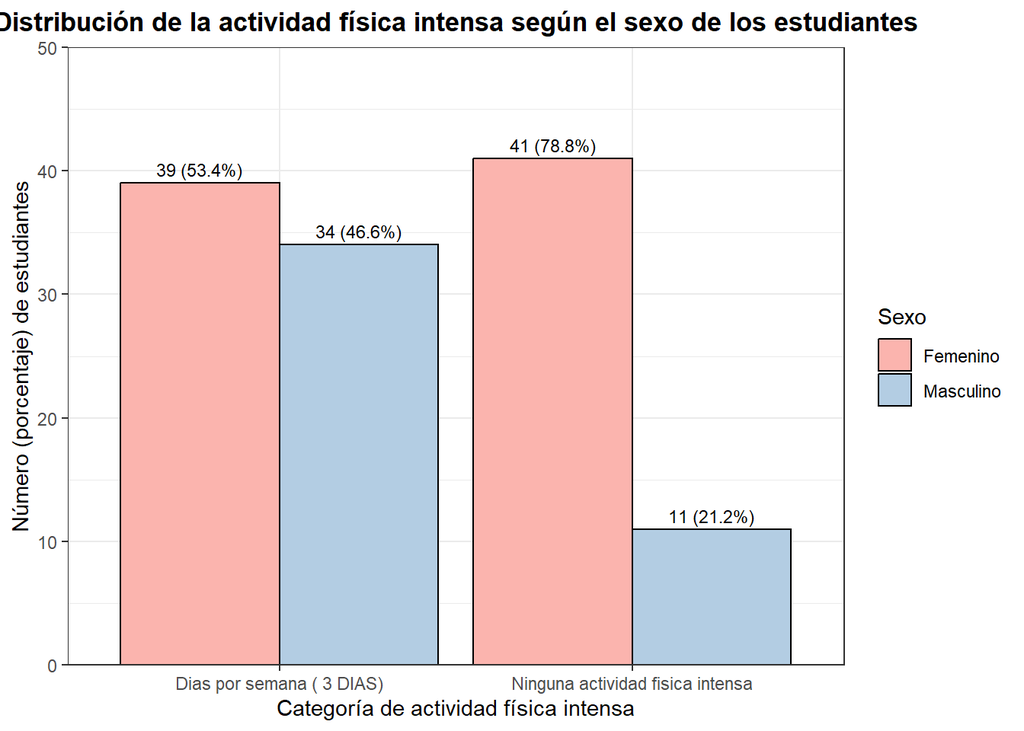

La distribución de la actividad física intensa según el sexo de los estudiantes muestra diferencias importantes entre los grupos. En la categoría de realizar actividad física intensa al menos 3 días por semana, el 53.4% (n = 39) de los estudiantes son mujeres, mientras que el 46.6% (n = 34) son hombres. Por otro lado, en la categoría de no realizar ninguna actividad física intensa, el 78.8% (n = 41) son mujeres, mientras que solo el 21.2% (n = 11) son hombres.

Estos resultados sugieren que una mayor proporción de mujeres no participa en actividades físicas intensas en comparación con los hombres, quienes muestran una participación más equilibrada entre ambas categorías. Esto podría reflejar diferencias en hábitos, preferencias o barreras para realizar actividades físicas intensas entre ambos sexos en la muestra analizada.

```
##
##  Pearson's Chi-squared test with Yates' continuity correction
##
## data:  tabla
## X-squared = 7.4503, df = 1, p-value = 0.006342
```

La prueba Chi-cuadrado de Pearson nos indica que existe una asociación ($\chi^2=7.4503$, p-valor = 0.006342) estadísticamente significativas entre el sexo (femenino y masculino) y la frecuencia de actividades físicas intensas realizadas durante los últimos 7 días.

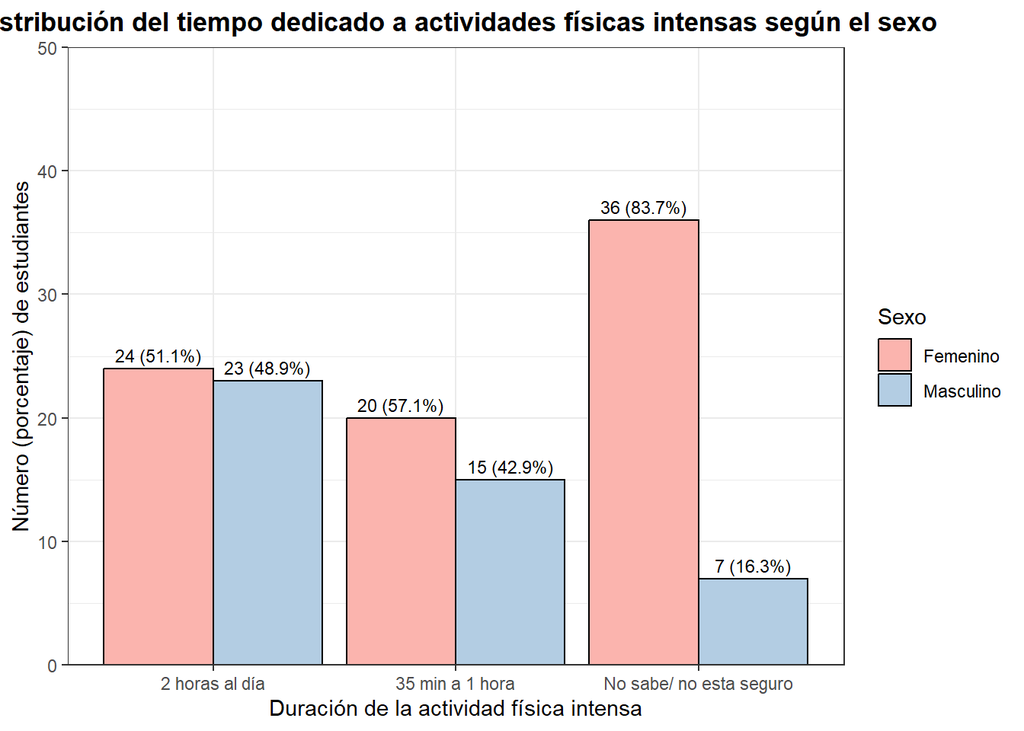

La distribución del tiempo dedicado a actividades físicas intensas según el sexo revela diferencias claras entre los estudiantes. En la categoría de 2 horas al día, la distribución está bastante equilibrada, con un 51.1% (n = 24) de mujeres y un 48.9% (n = 23) de hombres. Sin embargo, en la categoría de 35 minutos a 1 hora, las mujeres representan el 57.1% (n = 20) frente al 42.9% (n = 15) de hombres, mostrando una mayor proporción de participación femenina en este rango de tiempo.

Por otro lado, en la categoría “No sabe/No está seguro”, existe una diferencia mucho más marcada: el 83.7% (n = 36) corresponde a mujeres, mientras que solo el 16.3% (n = 7) son hombres. Esto sugiere que las mujeres tienen una mayor proporción de incertidumbre o falta de registro sobre el tiempo que dedican a actividades físicas intensas.

Estos resultados indican que, si bien la participación en actividades físicas intensas es relativamente equilibrada en algunos rangos de tiempo, las mujeres tienden a tener una mayor proporción en los niveles de menor claridad sobre la duración de estas actividades. Esto podría estar relacionado con diferencias en la percepción o el seguimiento de la actividad física entre ambos sexos.

```
##
##  Pearson's Chi-squared test
##
## data:  tabla
## X-squared = 11.386, df = 2, p-value = 0.003369
```

La prueba Chi-cuadrado de Pearson nos indica que existe una asociación ($\chi^2=11.386$,valor=0.003369) estadísticamente significativa entre el sexo (femenino y masculino) y la duración del tiempo dedicado a actividades físicas intensas. Esto sugiere que la distribución de los diferentes niveles de duración de las actividades físicas intensas varía significativamente entre hombres y mujeres en la muestra analizada.

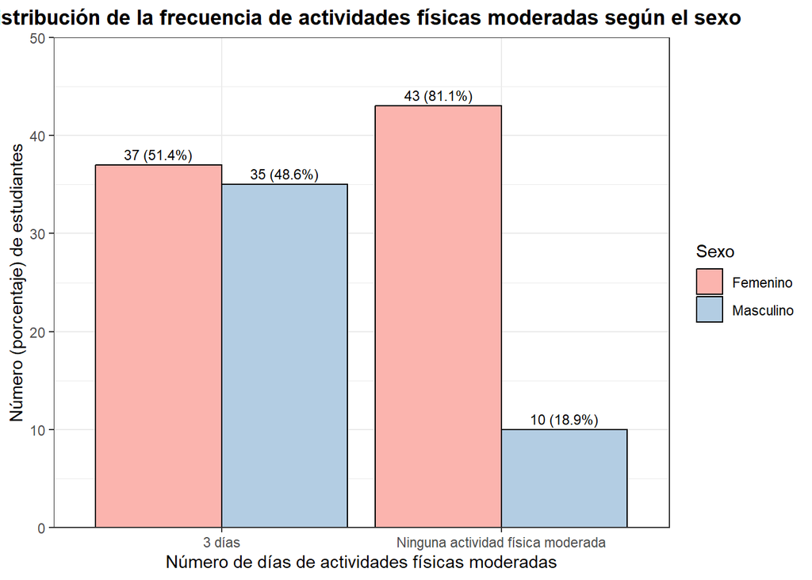

La distribución del número de días dedicados a actividades físicas moderadas según el sexo muestra diferencias significativas entre los grupos. En la categoría de realizar actividades físicas moderadas durante 3 días en la última semana, la proporción entre mujeres y hombres es similar, con un 51.4% (n = 37) de mujeres y un 48.6% (n = 35) de hombres.

Sin embargo, en la categoría de no realizar ninguna actividad física moderada, la diferencia es notable: el 81.1% (n = 43) corresponde a mujeres, mientras que solo el 18.9% (n = 10) son hombres.

Estos resultados sugieren que una proporción considerablemente mayor de mujeres no participa en actividades físicas moderadas en comparación con los hombres. Esto podría reflejar diferencias en hábitos, preferencias o barreras para la práctica de actividades físicas moderadas entre los sexos en la muestra analizada.

```
##
##  Pearson's Chi-squared test with Yates' continuity correction
##
## data:  tabla
## X-squared = 10.466, df = 1, p-value = 0.001216
```

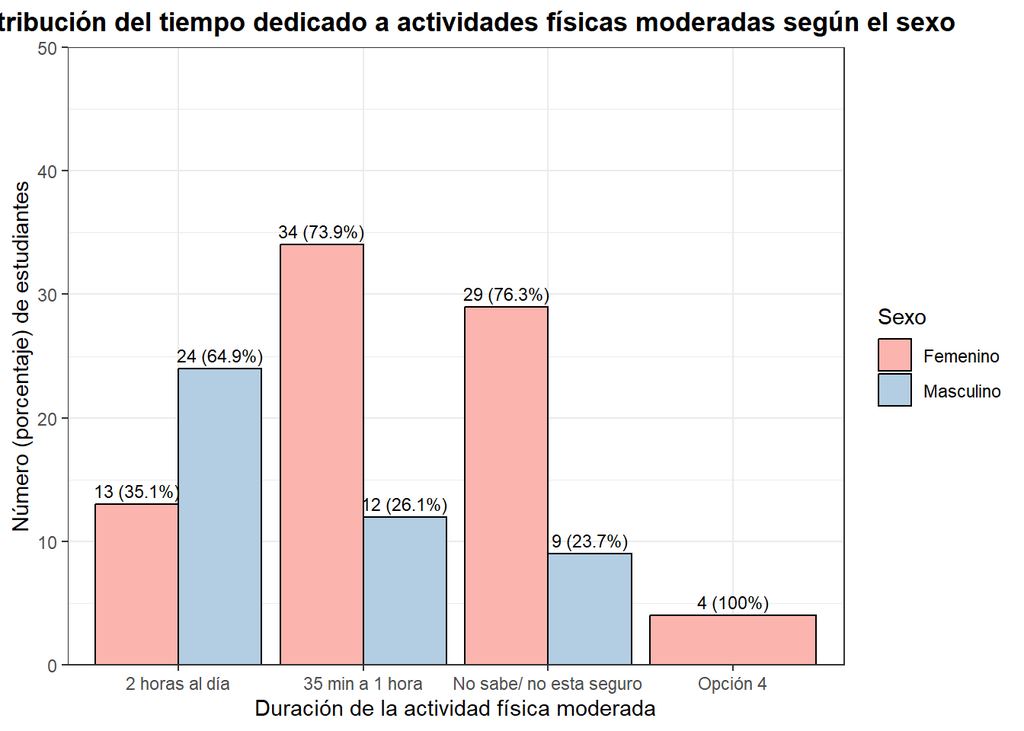

La distribución del tiempo dedicado a actividades físicas moderadas según el sexo muestra diferencias significativas entre hombres y mujeres. En la categoría de 2 horas al día, el 64.9% (n = 24) corresponde a hombres, mientras que el 35.1% (n = 13) son mujeres. Por otro lado, en la categoría de 35 minutos a 1 hora, las mujeres representan el 73.9% (n = 34), frente al 26.1% (n = 12) de los hombres, mostrando una mayor proporción femenina en esta duración.

En la categoría “No sabe/no está seguro”, las mujeres también predominan, representando el 76.3% (n = 29), mientras que los hombres son el 23.7% (n = 9). Finalmente, en la categoría “Opción 4”, únicamente mujeres (100%, n = 4) seleccionaron esta opción.

Estos resultados sugieren que los hombres tienen una mayor representación en los períodos de actividad física moderada más largos (2 horas al día), mientras que las mujeres predominan tanto en la categoría intermedia (35 minutos a 1 hora) como en la incertidumbre respecto al tiempo dedicado. Esto podría reflejar diferencias en percepción, hábitos o registro de la actividad física entre ambos grupos.

```
##
##  Pearson's Chi-squared test with simulated p-value (based on 5000
##  replicates)
##
## data:  tabla
## X-squared = 20.094, df = NA, p-value = 2e-04
```

La prueba Chi-cuadrado de Pearson, con un p-valor simulado basado en 5000 réplicas, nos indica que existe una asociación ($\chi^2=20.094$, p-valor=1.9996001^{-4}) estadísticamente significativa entre el sexo (femenino y masculino) y la duración del tiempo dedicado a actividades físicas moderadas. Esto sugiere que la distribución de los diferentes niveles de duración de las actividades físicas moderadas varía significativamente entre hombres y mujeres en la muestra analizada.

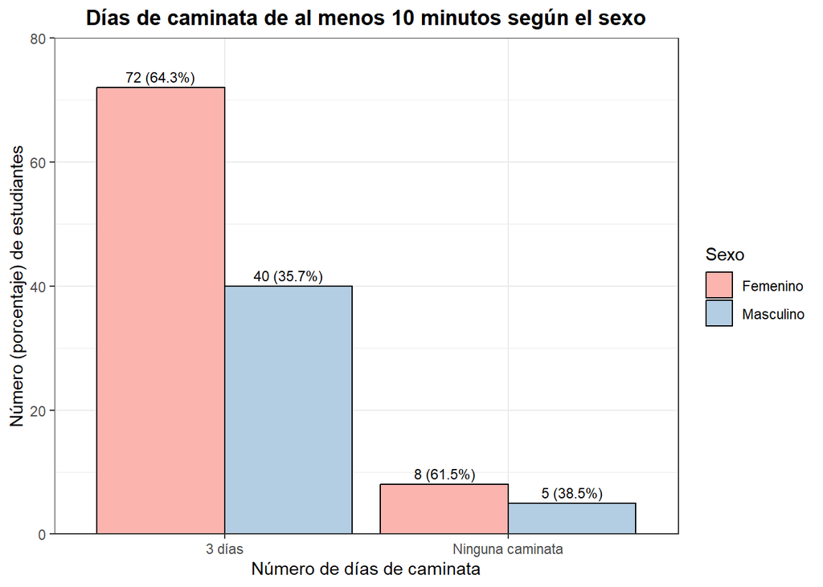

Por otro lado, en la categoría “Ninguna caminata”, las mujeres representan el 61.5% (n = 8), mientras que los hombres son el 38.5% (n = 5).

```
##
##  Pearson's Chi-squared test with simulated p-value (based on 5000
##  replicates)
##
## data:  tabla
## X-squared = 0.038156, df = NA, p-value = 1
```

La prueba Chi-cuadrado de Pearson, con un p-valor simulado basado en 5000 réplicas, nos indica que no existe una asociación ($\chi^2=0.038156$, p-valor=1) estadísticamente significativa entre el sexo (femenino y masculino) y el número de días que los estudiantes caminaron al menos 10 minutos. Esto sugiere que la distribución de los diferentes niveles de caminata no varía significativamente entre hombres y mujeres en la muestra analizada.

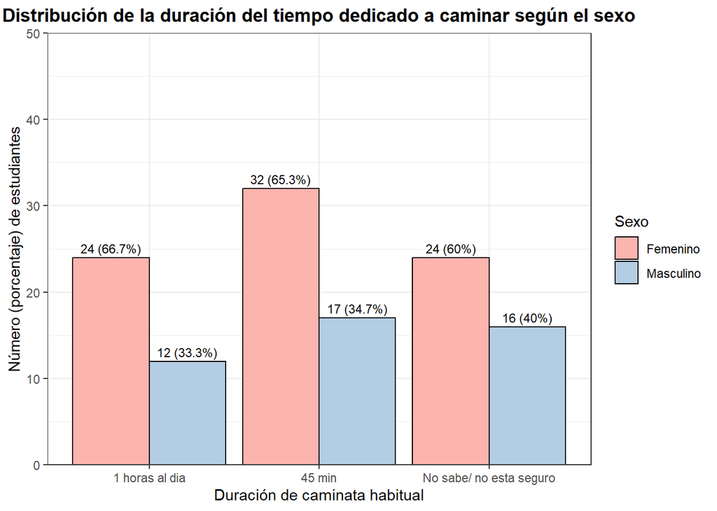

En la categoría de caminar “45 minutos”, las mujeres también predominan, representando el 65.3% (n = 32), frente al 34.7% (n = 17) de hombres. Finalmente, en la categoría “No sabe/no está seguro”, el 60% (n = 24) son mujeres, mientras que el 40% (n = 16) son hombres.

```
##
##  Pearson's Chi-squared test
##
## data:  tabla
## X-squared = 0.42517, df = 2, p-value = 0.8085
```

La prueba Chi-cuadrado de Pearson nos indica que no existe una asociación ($\chi^2=0.4252$, p-valor=0.8085) estadísticamente significativa entre el sexo (femenino y masculino) y la duración del tiempo dedicado a caminar. Esto sugiere que la distribución de los diferentes niveles de duración de caminata no varía significativamente entre hombres y mujeres en la muestra analizada.

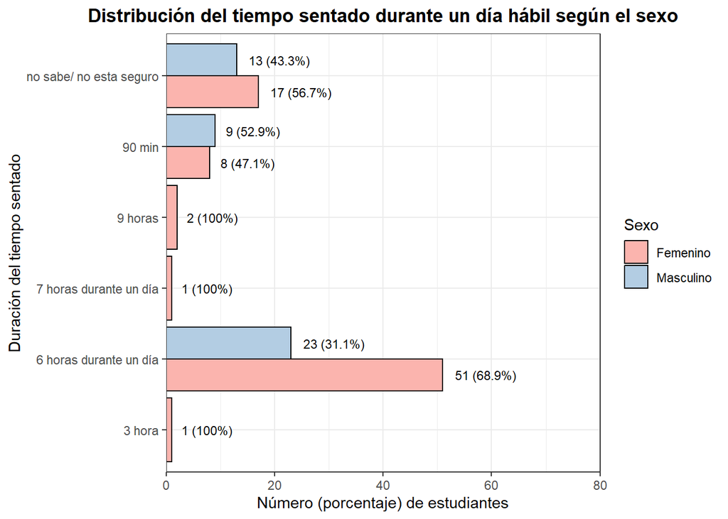

```
##
##  Pearson's Chi-squared test with simulated p-value (based on 5000
##  replicates)
##
## data:  tabla
## X-squared = 5.845, df = NA, p-value = 0.3061
```

La prueba Chi-cuadrado de Pearson, con un p-valor simulado basado en 5000 réplicas, nos indica que no existe una asociación($\chi^2=5.845$, p-valor=0.3061388) estadísticamente significativa entre el sexo (femenino y masculino) y la duración del tiempo que los estudiantes pasaron sentados durante un día hábil. Esto sugiere que la distribución de los diferentes niveles de tiempo sentado no varía significativamente entre hombres y mujeres en la muestra analizada.